# Python 🐍

Para no programadores

David García Garzón

# Sesión 1 2020-02-06 🐍

# Introducción

## Objetivo

Introducir el lenguaje de programación Python a personas del ET que no hayan programado nunca

Dos sesiones estilo *manos a la obra* (hands-on)

Meta: Leer una hoja de cálculo, procesarla y generar un informe con cara y ojos

Los ejemplos de la presentación los podeis copiar en vuestros ordenadores de la versión on-line

## Código Máquina

Programamos para decirle al ordenador qué hacer

El ordenador solo entiende **código máquina**:  
01000111001… binario ininteligible para humanos

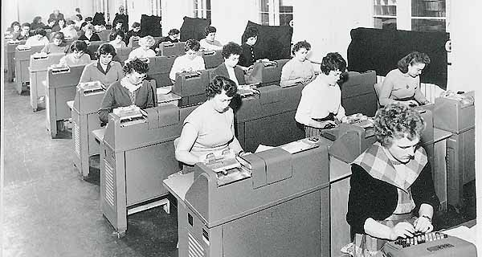

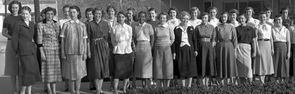

…para casi todos

## Código fuente

(El resto) usamos lenguajes intermedios  
para comunicarnos con la máquina

Los **lenguajes de programación** nos abstraen de la máquina para concentrarnos en el problema,

y, así, llegar [más lejos](https://github.com/casper-astro?language=python):

¿Cómo se pasa de **Código fuente** a **Código máquina**?

[figure not shown]

## Compiladores e intérpretes

**Compilador**

*Traductor de libros*

Genera un ejecutable

Se ejecuta el binario, sin código ni compilador

C, C++, Java, Pascal…

**Intérprete**

*Traducción simultanea*

Ejecuta mientras interpreta

Necesitas interprete y código para ejecutar

Python, Perl, Bash, PHP…

## Python mola

Es muy fácil de aprender

No te limita cuando quieres crecer

No (solo) para jugar: ciencia, negocios…

Hay librerías para todo

Mucha comunidad

Se llama así por los [Monty Python](https://es.wikipedia.org/wiki/Monty_Python)  
Tiene huevos de pascua…

## Elementos

Lenguaje: [Tutorial oficial](https://docs.python.org/3/tutorial/)

Librería estandard: [Referencia](https://docs.python.org/3/library/)

Librerías no estándards: [Repositorio](https://pypi.org/)

Tened los enlaces a mano para consulta

Disclaimer: todo en inglés

## Instalación

Linux

```bash
$ sudo apt install ipython3
```

Windows

[Anaconda](https://conda.io/)

## Ejecución interactiva

Intérprete interactivo: `ipython3`

Ideal para pruebas rápidas

```python
>>> print("hola mundo")
hola mundo
```

Completa o explora con el tabulador

Recupera la historia con el cursor arriba

## Scripts

Cuando el código se complica,  
mejor meterlo en un fichero (script)

```python
# miscript.py
print("hola mundo")
```

Se ejecuta:

```bash
$ python3 miscript.py
hola mundo
```

## Sintaxis general

```python
# Despues de la almohadilla son comentarios, los ignora
print("Hola Mundo") # Una sentencia por línia
print("Hola caracola")

# Sentencias con ':' empiezan subsentencias indentadas
if True:
    print("Primera subsentencia")
    print("Segunda subsentencia")
print("Esta ya esta fuera")

if True:
    if False:
        print("Dentro del if False")
    print("Dentro del if True")
```

## Gamberreando

```python
# Los signos que abren y cierran permiten partir líneas
print(
    "Hola mundo"
)

# A muy malas con la contrabarra al final de línea
print \
    ("Hola mundo")

# Punto y coma para juntar dos sentencias
print("Marco"); print("Polo")

# Tambien podemos poner en una ĺínia las subsentencias
if True: print("subsentencia rápida")
```